# Cleaning up Junior Race Week

Mara Averick

2019-07-27

I [came across](https://twitter.com/dataandme/status/1154532351235547138) the list of registrants for the 2019 Marblehead Junior Race Week (MJRW) in the local paper, and was kind of appalled by the lack of data cleaning. Indignant outrage without action is cheap, so I thought I’d give it a go myself.

After a few attempts using [rvest](https://rvest.tidyverse.org/index.html), I discovered that the data is, indeed, in a super nasty format (aren’t `iframes` fun, kids?), and had to go to copy-pasta-ing. But, aside from that (as well the removal of annoying 🇺🇸 flags, and addition of a `Class` variable), the data is still pretty gross. In fact, I’m keeping the window with the [results online](https://www.regattatoolbox.com/results?eventID=8tDOrn7dbe) open as I go to help me parse the madness.

## Packages

```r
library(tidyverse)
library(here)
```

## Import and inspect

*Note: After doing and writing all of this up, I found a different data source that completely changed how I would do this the next time!*

Because each class (420 Champ, 420 Green, Laser, Opti Champ, and Opti Green) has its own structure (i.e. the column headers are not the same), I’ll have to deal with them one by one. However, I’ll try to use strategies that are generalizable to the other datasets.

```r
mjrw_2019_420_champ <- read_csv(here::here("data", "raw", "mjrw_2019_420_champ.csv"),
    col_types = cols(Position = col_integer()))

mjrw_2019_420_champ
```

```
## # A tibble: 76 x 12
##    Class Position `Sail Number` `Sailor(s)` `Boat Name/Club` Points R1
##    <chr>    <int> <chr>         <chr>       <chr>             <dbl> <chr>
##  1 420 …        1 <NA>          Brooks Reed Hingham Yacht C…      8 1
##  2 420 …       NA USA 871       Trent Hess… <NA>                 NA <NA>
##  3 420 …        2 <NA>          Sawyer Reed Hingham Yacht C…     20 2
##  4 420 …       NA USA 8241      Andrew Eng… <NA>                 NA <NA>
##  5 420 …        3 <NA>          James Know… Buck's Harbor Y…     21 5
##  6 420 …       NA USA 1905      Sloan Phil… <NA>                 NA <NA>
##  7 420 …        4 <NA>          Ian McCaff… Kiss My Transom      22 3
##  8 420 …       NA USA 2296      Katy Benagh Sandy Bay Yacht…     NA <NA>
##  9 420 …        5 <NA>          Sandy Yale  Portland Yacht …     28 8
## 10 420 …       NA USA 6906      Elsa Dean-… <NA>                 NA <NA>
## # … with 66 more rows, and 5 more variables: R2 <chr>, R3 <chr>, R4 <chr>,
## #   R5 <chr>, R6 <chr>
```

So, WTF is going on here? Let’s look at [the source](https://www.regattatoolbox.com/results?eventID=8tDOrn7dbe) and see:

[figure not shown]

420 Champ results

The first difference you probably see is that we’ve got an abundance of `NA`s, while the original table does not (mainly because there’s a bunch of annoying *merged cell* stuff going on behind the scenes). Each boat (identified by `Sail Number`) has multiple `Sailor(s)`, and the data seems to get oddly divvied up between the two: the `Position` value shows up with the first sailor’s name, while the `Sail Number` is down in the row below with the latter. There’s also the matter of the decidedly *untidy* `Boat Name/Club` variable, which contains more than one piece of information.

I’m going to subset the data frame by `Sailor(s)` for illustration purposes, below.[^1]

```r
select_sailors <- c("Brooks Reed", "Trent Hesselman", "Ian McCaffrey", "Katy Benagh")

mjrw_2019_420_champ %>%
  filter(`Sailor(s)` %in% select_sailors)
```

```
## # A tibble: 4 x 12
##   Class Position `Sail Number` `Sailor(s)` `Boat Name/Club` Points R1
##   <chr>    <int> <chr>         <chr>       <chr>             <dbl> <chr>
## 1 420 …        1 <NA>          Brooks Reed Hingham Yacht C…      8 1
## 2 420 …       NA USA 871       Trent Hess… <NA>                 NA <NA>
## 3 420 …        4 <NA>          Ian McCaff… Kiss My Transom      22 3
## 4 420 …       NA USA 2296      Katy Benagh Sandy Bay Yacht…     NA <NA>
## # … with 5 more variables: R2 <chr>, R3 <chr>, R4 <chr>, R5 <chr>,
## #   R6 <chr>
```

### Data modelling

Now’s a good moment to pause and think about how we want our data to look in the end – for now, we’ll ignore the actual results section. We *could* turn `Sailor(s)` into a list column, but I’d rather give each sailor their own row. We also need to separate boat and club names into their own columns, e.g. `Boat Name` and `Club`.

So, I’m hoping for the data to look something like this, in the end:

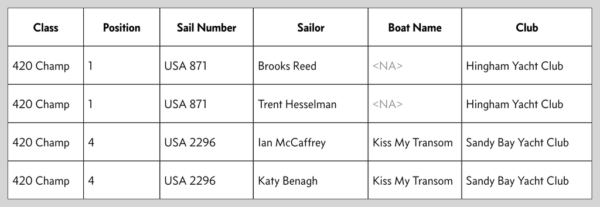

420 Champ – clean-data vision

**How do we get from here to there?**

The pair that came in first didn’t have their own boat, which can make things look misleadingly simple:

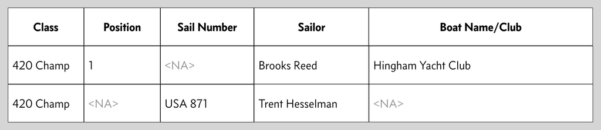

420 Champ - Position 1

For the pair that came in fourth, you wouldn’t be able to use this same strategy until *after* `Boat Name/Club` has been separated into two columns:

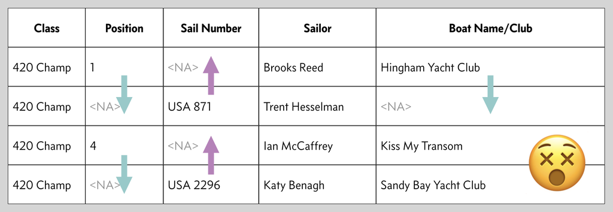

420 Champ data unseparated

Once you’ve separated `Boat Name` and `Club`, you could fill up and down, like so:

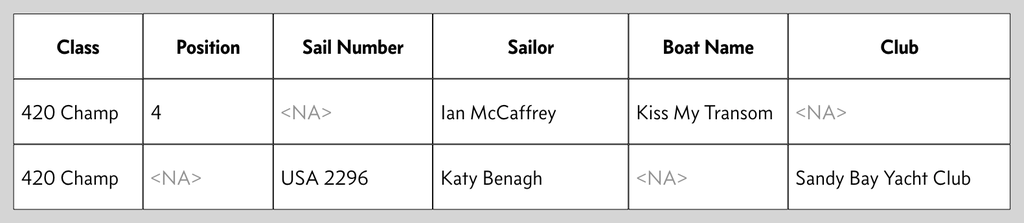

420 Champ - Position 4

But, how do I tell a computer about this? The only reason I know to put “Kiss My Transform” as `Boat Name` is because it would be a super weird name for a yacht club.

This also means that the “directions” for filling the data depend on whether or not there is a boat name or not:

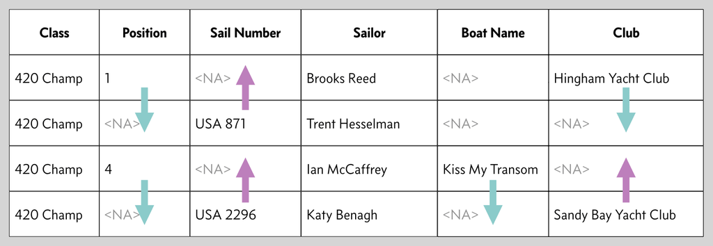

420 Champ - fill with or without boat

## Putting the plan into action

Because the order of the rows is important, I’m going to add a `rowid` variable with [`tibble::rowid_to_column()`](https://tibble.tidyverse.org/reference/rownames.html). I like this because it automatically puts `rowid` as the first column.

The [`tidyr::fill()`](https://tidyr.tidyverse.org/reference/fill.html) function is handy for, well, filling in data. There were two columns in the mockups above that filled in the same direction regardless of whether or not there was a boat name: `Position`, and `Sail Number`. The `Points` and other scoring columns (not shown in the data model) work the same way as `Position` – i.e. should fill *down*, regardless of whether `Boat Name/Club` is a boat name or a club name.

I’ll reference “the rest of those columns” by creating a collection of the variables we looked at. I’ll use tidyselect to grab “the first column through `Boat Name/Club`”, and then get the column names using `colnames()`.

```r
mjrw_2019_420_champ %>%
  select(1:`Boat Name/Club`) %>%
  colnames() -> specialcols

specialcols
```

```
## [1] "Class"          "Position"       "Sail Number"    "Sailor(s)"
## [5] "Boat Name/Club"
```

In `tidyr::fill()`, the default for the `.direction` argument is `"down"`. So I *must* specify that the fill `.direction` for `Sail Number` should be `"up"`, but I’ll provide an argument to `.direction` in all cases for clarity.

```r
mjrw_420_champ <- mjrw_2019_420_champ %>%
  rowid_to_column() %>%
  fill(`Sail Number`, .direction = "up") %>%
  fill(Position, .direction = "down") %>%
  fill(-one_of(specialcols), .direction = "down") # fill down the rest


mjrw_420_champ %>%
  filter(`Sailor(s)` %in% select_sailors)
```

```
## # A tibble: 4 x 13
##   rowid Class Position `Sail Number` `Sailor(s)` `Boat Name/Club` Points
##   <int> <chr>    <int> <chr>         <chr>       <chr>             <dbl>
## 1     1 420 …        1 USA 871       Brooks Reed Hingham Yacht C…      8
## 2     2 420 …        1 USA 871       Trent Hess… <NA>                  8
## 3     7 420 …        4 USA 2296      Ian McCaff… Kiss My Transom      22
## 4     8 420 …        4 USA 2296      Katy Benagh Sandy Bay Yacht…     22
## # … with 6 more variables: R1 <chr>, R2 <chr>, R3 <chr>, R4 <chr>,
## #   R5 <chr>, R6 <chr>
```

To figure out this pesky boat-name business, I also want to add a variable that counts up the number of if this is the first or second observation per boat (we can use `Sail Number` or `Position` as a proxy for this). I’m filtering to `select_sailors` to make it a bit easier to see how it relates to the data model.

```r
mjrw_420_champ %>%
  dplyr::group_by(`Sail Number`) %>%
  dplyr::mutate(sailor_count = dplyr::row_number()) %>%
  filter(`Sailor(s)` %in% select_sailors)
```

```
## # A tibble: 4 x 14
## # Groups:   Sail Number [2]
##   rowid Class Position `Sail Number` `Sailor(s)` `Boat Name/Club` Points
##   <int> <chr>    <int> <chr>         <chr>       <chr>             <dbl>
## 1     1 420 …        1 USA 871       Brooks Reed Hingham Yacht C…      8
## 2     2 420 …        1 USA 871       Trent Hess… <NA>                  8
## 3     7 420 …        4 USA 2296      Ian McCaff… Kiss My Transom      22
## 4     8 420 …        4 USA 2296      Katy Benagh Sandy Bay Yacht…     22
## # … with 7 more variables: R1 <chr>, R2 <chr>, R3 <chr>, R4 <chr>,
## #   R5 <chr>, R6 <chr>, sailor_count <int>
```

Now we can find the sailors who have their own boats by looking for second sailors (`sailor_count == 2`) for whom `Boat Name/Club` is *not* `NA`. When that’s the case, the value of `Boat Name/Club` for the *first* sailor is the name of a boat.

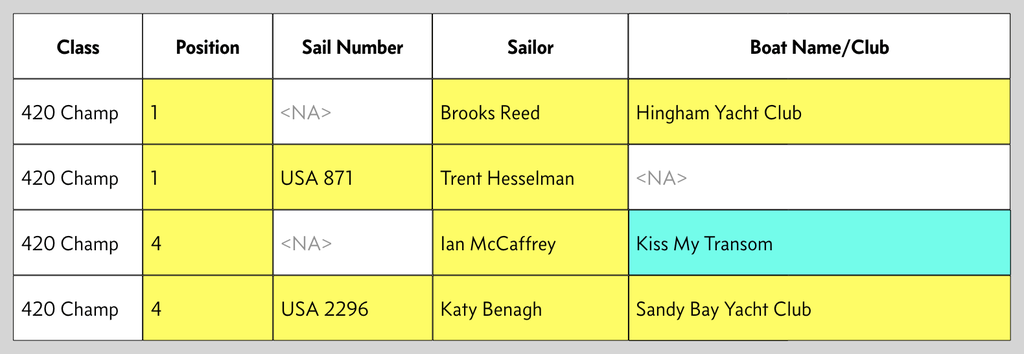

Non-`NA` values boat name or club

I’m creating two groups of “second sailors” (`sailor_count == 2`): those with boats, and those without (i.e. those for whom `Boat Name/Club` is `NA`). For all second sailors with boats, the value for `Boat Names/Club` will be the name of a club. So, we’ll rename the variable `Club`. For those *without* boats it is be definition `NA`, so we’ll drop the column.[^2]

```r
mjrw_420_champ <- mjrw_420_champ %>%
  dplyr::group_by(`Sail Number`) %>%
  dplyr::mutate(sailor_count = dplyr::row_number()) %>%
  ungroup()
```

```r
have_boats <- mjrw_420_champ %>%
  filter(sailor_count == 2) %>%
  drop_na(`Boat Name/Club`)

no_boats <- mjrw_420_champ %>%
  filter(sailor_count == 2) %>%
  anti_join(have_boats) %>% # get the ones we didn't drop
  select(-`Boat Name/Club`) # get rid of this column bc all NA
have_boats_clubs <- mjrw_420_champ %>%
  filter(sailor_count == 2) %>%
  drop_na(`Boat Name/Club`) %>%
  rename(Club = `Boat Name/Club`)

have_boats_clubs
```

```
## # A tibble: 4 x 14
##   rowid Class Position `Sail Number` `Sailor(s)` Club  Points R1    R2
##   <int> <chr>    <int> <chr>         <chr>       <chr>  <dbl> <chr> <chr>
## 1     8 420 …        4 USA 2296      Katy Benagh Sand…     22 3     8
## 2    30 420 …       15 USA 7742      Calvin May  Agam…     69 9     5
## 3    34 420 …       17 USA 8720      Kate Rogers Hing…     73 16    20
## 4    56 420 …       28 USA 8488      Nora McCar… Cott…    122 32    22
## # … with 5 more variables: R3 <chr>, R4 <chr>, R5 <chr>, R6 <chr>,
## #   sailor_count <int>
```

The names of the home club for groups without a boat is with their *first* sailor (`sailor_count == 1`):

```r
no_boats_clubs <- mjrw_420_champ %>%
  filter(Position %in% no_boats$Position,
         sailor_count == 1) %>%
  rename(Club = `Boat Name/Club`)

no_boats_clubs
```

```
## # A tibble: 34 x 14
##    rowid Class Position `Sail Number` `Sailor(s)` Club  Points R1    R2
##    <int> <chr>    <int> <chr>         <chr>       <chr>  <dbl> <chr> <chr>
##  1     1 420 …        1 USA 871       Brooks Reed Hing…      8 1     1
##  2     3 420 …        2 USA 8241      Sawyer Reed Hing…     20 2     3
##  3     5 420 …        3 USA 1905      James Know… Buck…     21 5     7
##  4     9 420 …        5 USA 6906      Sandy Yale  Port…     28 8     2
##  5    11 420 …        6 USA 10        Gunnar Nee  Coha…     28 4     4
##  6    13 420 …        7 USA 8497      Porter Bell Hing…     30 12    -13
##  7    15 420 …        8 USA 7273      Ben Trotsky Sand…     34 6     6
##  8    17 420 …        9 USA 8696      Nathan Sel… Harr…     44 11    14
##  9    19 420 …       10 USA 781       Ashley Hog… Pleo…     53 15    11
## 10    21 420 …       11 USA 6905      Samuel Roo… Port…     62 -29   16
## # … with 24 more rows, and 5 more variables: R3 <chr>, R4 <chr>, R5 <chr>,
## #   R6 <chr>, sailor_count <int>
```

OK, so we know which positions have boats. Let’s get the boat names. Again, we’ll rename our variable to fit the contents.

```r
sails_names <- mjrw_420_champ %>%
  filter(Position %in% have_boats$Position,
         sailor_count == 1) %>%
  rename(`Boat Name` = `Boat Name/Club`) %>%
  select(Position, `Sail Number`, `Boat Name`)

sails_names
```

```
## # A tibble: 4 x 3
##   Position `Sail Number` `Boat Name`
##      <int> <chr>         <chr>
## 1        4 USA 2296      Kiss My Transom
## 2       15 USA 7742      debie mcsweeney
## 3       17 USA 8720      Ellen Rogers
## 4       28 USA 8488      Fight Club
```

We can now isolate this in a lookup table of sorts by combining our `Club` and `Boat Name` data for each group. Since *most* groups do not have a boat name, most of the `Boat Name` observations will be `NA`.

```r
info_by_sails <- sails_clubs %>%
  left_join(sails_names)
info_by_sails
```

[output not shown]

```
## # A tibble: 38 x 4
##    Position `Sail Number` Club                     `Boat Name`
##       <int> <chr>         <chr>                    <chr>
##  1        1 USA 871       Hingham Yacht Club       <NA>
##  2        2 USA 8241      Hingham Yacht Club       <NA>
##  3        3 USA 1905      Buck's Harbor Yacht Club <NA>
##  4        4 USA 2296      Sandy Bay Yacht Club     Kiss My Transom
##  5        5 USA 6906      Portland Yacht Club      <NA>
##  6        6 USA 10        Cohasset Yacht Club      <NA>
##  7        7 USA 8497      Hingham Yacht Club       <NA>
##  8        8 USA 7273      Sandy Bay Yacht Club     <NA>
##  9        9 USA 8696      Harraseeket Yacht Club   <NA>
## 10       10 USA 781       Pleon YC                 <NA>
## # … with 28 more rows
```

### Put our boats and sailors back together…

Umm, let’s see. If all went according to plan, we should be able to join the `Boat Name` and `Club` to our modified data by `Position` and `Sail Number`. We can then get rid of pesky `Boat Name/Club`, and we’ll rename `Sailor(s)` to singular.

```r
clean_mjrw_420_champ <- mjrw_420_champ %>%
  left_join(info_by_sails) %>%
  select(-`Boat Name/Club`) %>%
  rename(Sailor = `Sailor(s)`) %>%
  select(1:Sailor, `Boat Name`, Club, everything())
clean_mjrw_420_champ
```

```
## # A tibble: 76 x 15
##    rowid Class Position `Sail Number` Sailor `Boat Name` Club  Points R1
##    <int> <chr>    <int> <chr>         <chr>  <chr>       <chr>  <dbl> <chr>
##  1     1 420 …        1 USA 871       Brook… <NA>        Hing…      8 1
##  2     2 420 …        1 USA 871       Trent… <NA>        Hing…      8 1
##  3     3 420 …        2 USA 8241      Sawye… <NA>        Hing…     20 2
##  4     4 420 …        2 USA 8241      Andre… <NA>        Hing…     20 2
##  5     5 420 …        3 USA 1905      James… <NA>        Buck…     21 5
##  6     6 420 …        3 USA 1905      Sloan… <NA>        Buck…     21 5
##  7     7 420 …        4 USA 2296      Ian M… Kiss My Tr… Sand…     22 3
##  8     8 420 …        4 USA 2296      Katy … Kiss My Tr… Sand…     22 3
##  9     9 420 …        5 USA 6906      Sandy… <NA>        Port…     28 8
## 10    10 420 …        5 USA 6906      Elsa … <NA>        Port…     28 8
## # … with 66 more rows, and 6 more variables: R2 <chr>, R3 <chr>, R4 <chr>,
## #   R5 <chr>, R6 <chr>, sailor_count <int>
```

```r
write_csv(clean_mjrw_420_champ, here::here("data", "clean", "420_champ.csv"))
```

## Other datasets?

Oh yeah, those… It’s probably time to consider some function writing and refactoring. Here’s the copy pasta involved with just “redoing” everything from above, and it is not pretty.

```r
mjrw_2019_420_green <- read_csv(here::here("data", "raw", "mjrw_2019_420_green.csv"),
                                col_types = cols(Position = col_integer()))

mjrw_2019_420_green %>%
  select(1:`Boat Name/Club`) %>%
  colnames() -> specialcols
```

```r
mjrw_420_green <- mjrw_2019_420_green %>%
  rowid_to_column() %>%
  fill(`Sail Number`, .direction = "up") %>%
  fill(Position, .direction = "down") %>%
  fill(-one_of(specialcols), .direction = "down") %>%
  dplyr::group_by(`Sail Number`) %>%
  dplyr::mutate(sailor_count = dplyr::row_number()) %>%
  ungroup()
```

```r
have_boats <- mjrw_420_green %>%
  filter(sailor_count == 2) %>%
  drop_na(`Boat Name/Club`)

no_boats <- mjrw_420_green %>%
  filter(sailor_count == 2) %>%
  anti_join(have_boats) %>% # get the ones we didn't drop
  select(-`Boat Name/Club`) # get rid of this column bc all NA
have_boats_clubs <- mjrw_420_green %>%
  filter(sailor_count == 2) %>%
  drop_na(`Boat Name/Club`) %>%
  rename(Club = `Boat Name/Club`)

no_boats_clubs <- mjrw_420_green %>%
  filter(Position %in% no_boats$Position,
         sailor_count == 1) %>%
  rename(Club = `Boat Name/Club`)
```

```r
sails_clubs <- have_boats_clubs %>%
  bind_rows(no_boats_clubs) %>%
  select(Position, `Sail Number`, Club) %>%
  arrange(Position)

sails_names <- mjrw_420_green %>%
  filter(Position %in% have_boats$Position,
         sailor_count == 1) %>%
  rename(`Boat Name` = `Boat Name/Club`) %>%
  select(Position, `Sail Number`, `Boat Name`)

info_by_sails <- sails_clubs %>%
  left_join(sails_names)
clean_mjrw_420_green <- mjrw_420_green %>%
  left_join(info_by_sails) %>%
  select(-`Boat Name/Club`) %>%
  rename(Sailor = `Sailor(s)`) %>%
  select(1:Sailor, `Boat Name`, Club, everything())
```

**Note!** Here’s where having discovered that other file comes in. What made me want to clean this dataset up was the fact that the names of the clubs weren’t at all normalized. Turns out that there was a table of “All Classes” that *just* listed registrants – making club-name cleaning easier. I’ll read in a lookup table for raw club strings and their correctly-named counterparts. I also corrected the club names in the dataset with *just* registrant name (no results of the race).

```r
clubs <- read_csv(here::here("data", "clean", "clubs.csv"))
all_classes <- read_csv(here::here("data", "clean", "all_classes.csv"))
clean_mjrw_420_green %>%
  left_join(all_classes)
```

```
## # A tibble: 70 x 15
##    rowid Class Position `Sail Number` Sailor `Boat Name` Club  Points R1
##    <int> <chr>    <int> <chr>         <chr>  <chr>       <chr>  <dbl> <chr>
##  1     1 420 …        1 USA 1247      Max W… <NA>        Pleon     24 2
##  2     2 420 …        1 USA 1247      Ryan … <NA>        Pleon     24 2
##  3     3 420 …        2 USA 8767      Charl… <NA>        MSA       25 11
##  4     4 420 …        2 USA 8767      Sam P… <NA>        MSA       25 11
##  5     5 420 …        3 USA 8244      Fish … <NA>        Hing…     25 6
##  6     6 420 …        3 USA 8244      Cathe… <NA>        Hing…     25 6
##  7     7 420 …        4 USA 8240      Will … <NA>        Hing…     26 3
##  8     8 420 …        4 USA 8240      Wilso… <NA>        Hing…     26 3
##  9     9 420 …        5 USA 8243      Willi… <NA>        Hing…     31 4
## 10    10 420 …        5 USA 8243      Charl… <NA>        Hing…     31 4
## # … with 60 more rows, and 6 more variables: R2 <chr>, R3 <chr>, R4 <chr>,
## #   R5 <chr>, sailor_count <int>, `Club Name` <chr>
```

```r
write_csv(clean_mjrw_420_green, here::here("data", "clean", "420_green.csv"))
```

[^1]: Yes, it turns out there *are* actually two records that have `NA` for `Sailor(s)`, which is weird, bc I’m pretty sure this was a two-handed race.
[^2]: Note, it is not the name of their club. That data is with the first sailor in cases where there is no boat name.